# 02_Frequencies

2025-03-11

```r
library(CCA)
library(dplyr)
library(ggplot2)
library(reshape2)
library(ggridges)
library(gridExtra)
library(patchwork)
library(FactoMineR)
```

## Load

Loading Pre-processed data provided

```r
## load
load(here::here("Data", "ProcessedData", "processed_AnalysisData.Rdata"))
```

```r
processed_data
```

```
## # A tibble: 14,575 × 484
##    fishNum dateSample dateTimeSample      dateProcessed species   spCode
##    <chr>   <date>     <dttm>              <date>        <chr>      <dbl>
##  1 LT001   2022-07-21 2022-07-21 16:56:00 2022-07-27    lakeTrout     81
##  2 LT001   2022-07-21 2022-07-21 16:56:00 2022-07-27    lakeTrout     81
##  3 LT001   2022-07-21 2022-07-21 16:56:00 2022-07-27    lakeTrout     81
##  4 LT001   2022-07-21 2022-07-21 16:56:00 2022-07-27    lakeTrout     81
##  5 LT001   2022-07-21 2022-07-21 16:56:00 2022-07-27    lakeTrout     81
##  6 LT001   2022-07-21 2022-07-21 16:56:00 2022-07-27    lakeTrout     81
##  7 LT001   2022-07-21 2022-07-21 16:56:00 2022-07-27    lakeTrout     81
##  8 LT001   2022-07-21 2022-07-21 16:56:00 2022-07-27    lakeTrout     81
##  9 LT001   2022-07-21 2022-07-21 16:56:00 2022-07-27    lakeTrout     81
## 10 LT001   2022-07-21 2022-07-21 16:56:00 2022-07-27    lakeTrout     81
## # ℹ 14,565 more rows
## # ℹ 478 more variables: totalLength <dbl>, forkLength <dbl>, weight <dbl>,
## #   girth <dbl>, dorsoLatHeight <dbl>, clipTag <chr>, sex <chr>, mat <dbl>,
## #   airbladderTotalLength <dbl>, airBladderWidth <dbl>, airbladderWeight <dbl>,
## #   airBladderWeightCond <dbl>, agingStructure <chr>, tissueSample <chr>,
## #   Region_name <chr>, FishTrack <chr>, MaxTSdiff <dbl>, Ping_time <chr>,
## #   deltaRange <dbl>, deltaMinAng <dbl>, deltaMajAng <dbl>, …
```

```r
## variable names in data
names(processed_data)
```

```
##   [1] "fishNum"                       "dateSample"
##   [3] "dateTimeSample"                "dateProcessed"
##   [5] "species"                       "spCode"
##   [7] "totalLength"                   "forkLength"
##   [9] "weight"                        "girth"
##  [11] "dorsoLatHeight"                "clipTag"
##  [13] "sex"                           "mat"
##  [15] "airbladderTotalLength"         "airBladderWidth"
##  [17] "airbladderWeight"              "airBladderWeightCond"
##  [19] "agingStructure"                "tissueSample"
##  [21] "Region_name"                   "FishTrack"
##  [23] "MaxTSdiff"                     "Ping_time"
##  [25] "deltaRange"                    "deltaMinAng"
##  [27] "deltaMajAng"                   "aspectAngle"
##  [29] "Target_range"                  "Angle_minor_axis"
```

[output cut: 227 more lines]

Create a dataframe only containing frequencies.

```r
frequency_data <- (
  processed_data
  |> dplyr::select(1, 5, 59:484)
)
frequency_data |> head()
```

```
## # A tibble: 6 × 428
##   fishNum species     F45 F45.5   F46 F46.5   F47 F47.5   F48 F48.5   F49 F49.5
##   <chr>   <chr>     <dbl> <dbl> <dbl> <dbl> <dbl> <dbl> <dbl> <dbl> <dbl> <dbl>
## 1 LT001   lakeTrout -48.9 -47.5 -45.9 -44.2 -43.0 -41.7 -40.6 -39.6 -38.6 -37.7
## 2 LT001   lakeTrout -47.4 -47.6 -47.1 -45.5 -43.6 -41.6 -40.1 -39.0 -38.0 -37.2
## 3 LT001   lakeTrout -47.9 -49.3 -49.3 -47.2 -44.9 -42.7 -41.0 -39.5 -38.3 -37.2
## 4 LT001   lakeTrout -44.3 -45.7 -47.6 -48.8 -48.6 -46.7 -44.7 -42.9 -41.5 -40.3
## 5 LT001   lakeTrout -41.4 -42.3 -43.6 -44.7 -45.9 -46.6 -46.9 -46.7 -46.0 -45.1
## 6 LT001   lakeTrout -33.8 -33.7 -33.7 -33.5 -33.7 -33.8 -34.0 -34.1 -34.2 -34.2
## # ℹ 416 more variables: F50 <dbl>, F50.5 <dbl>, F51 <dbl>, F51.5 <dbl>,
## #   F52 <dbl>, F52.5 <dbl>, F53 <dbl>, F53.5 <dbl>, F54 <dbl>, F54.5 <dbl>,
## #   F55 <dbl>, F55.5 <dbl>, F56 <dbl>, F56.5 <dbl>, F57 <dbl>, F57.5 <dbl>,
## #   F58 <dbl>, F58.5 <dbl>, F59 <dbl>, F59.5 <dbl>, F60 <dbl>, F60.5 <dbl>,
## #   F61 <dbl>, F61.5 <dbl>, F62 <dbl>, F62.5 <dbl>, F63 <dbl>, F63.5 <dbl>,
## #   F64 <dbl>, F64.5 <dbl>, F65 <dbl>, F65.5 <dbl>, F66 <dbl>, F66.5 <dbl>,
## #   F67 <dbl>, F67.5 <dbl>, F68 <dbl>, F68.5 <dbl>, F69 <dbl>, F69.5 <dbl>, …
```

## Basic Frequencies

### Data cleaning

Since we notice the data of F90 to F170 are missing, we want to remove these frequencies columns from our dataset.

```r
## removing columns 93(F90) to 253(F170)
frequency_data <- frequency_data |> dplyr::select(-c(93:256))
## name(frequency_data)
```

Separate into three dataset for each species

```r
LakeTrout <- frequency_data[frequency_data$species == "lakeTrout", ]
LakeWhiteFish <- frequency_data[frequency_data$species == "lakeWhitefish", ]
SmallmouthBass <- frequency_data[frequency_data$species == "smallmouthBass", ]
```

### TS Mean Between Fish Species

We want to use the mean of target strength across all ping times of each fish across all frequencies to explore the dataset by fish species. We first create a dataframe that contains all mean values as above.

```r
ts_mean_allTime_data <- (
  frequency_data
  |> group_by(fishNum, species)
  |> mutate(species = recode(species,
                             "lakeTrout" = "Lake Trout",
                             "lakeWhitefish" = "Lake Whitefish",
                             "smallmouthBass" = "Smallmouth Bass"))
  |> summarize(across(starts_with("F"), ~mean(., na.rm = TRUE), .names = "{.col}_mean"))
)
ts_mean_allTime_data |> head()
```

```
## # A tibble: 6 × 264
## # Groups:   fishNum [6]
##   fishNum species    F45_mean F45.5_mean F46_mean F46.5_mean F47_mean F47.5_mean
##   <chr>   <chr>         <dbl>      <dbl>    <dbl>      <dbl>    <dbl>      <dbl>
## 1 LT001   Lake Trout    -46.3      -46.2    -46.3      -45.9    -45.4      -44.9
## 2 LT002   Lake Trout    -47.7      -47.3    -47.0      -46.6    -46.6      -46.4
## 3 LT003   Lake Trout    -47.3      -47.0    -46.8      -46.4    -46.3      -46.1
## 4 LT004   Lake Trout    -40.4      -40.3    -40.3      -40.0    -40.0      -39.8
## 5 LT005   Lake Trout    -60.5      -60.2    -60.1      -59.6    -59.7      -59.6
## 6 LT006   Lake Trout    -39.3      -39.2    -39.2      -38.9    -38.8      -38.6
## # ℹ 256 more variables: F48_mean <dbl>, F48.5_mean <dbl>, F49_mean <dbl>,
## #   F49.5_mean <dbl>, F50_mean <dbl>, F50.5_mean <dbl>, F51_mean <dbl>,
## #   F51.5_mean <dbl>, F52_mean <dbl>, F52.5_mean <dbl>, F53_mean <dbl>,
## #   F53.5_mean <dbl>, F54_mean <dbl>, F54.5_mean <dbl>, F55_mean <dbl>,
## #   F55.5_mean <dbl>, F56_mean <dbl>, F56.5_mean <dbl>, F57_mean <dbl>,
## #   F57.5_mean <dbl>, F58_mean <dbl>, F58.5_mean <dbl>, F59_mean <dbl>,
## #   F59.5_mean <dbl>, F60_mean <dbl>, F60.5_mean <dbl>, F61_mean <dbl>, …
```

We then melt the wide format dataframe into a long format dataframe for easy visualization.

```r
ts_mean_allTime_data_long <- (
  ts_mean_allTime_data
  |> melt(
    id.vars = c("fishNum", "species"),
    variable.name = "Frequency",
    value.name = "TS_mean_allTime"
  )
)

ts_mean_allTime_data_long$Frequency <- as.numeric(gsub("F([0-9.]+)_mean", "\\1",
                                                       ts_mean_allTime_data_long$Frequency))
ts_mean_allTime_data_long <- ts_mean_allTime_data_long |> arrange(fishNum, Frequency)
ts_mean_allTime_data_long |> head()
```

```
##   fishNum    species Frequency TS_mean_allTime
## 1   LT001 Lake Trout      45.0       -46.26963
## 2   LT001 Lake Trout      45.5       -46.18908
## 3   LT001 Lake Trout      46.0       -46.33088
## 4   LT001 Lake Trout      46.5       -45.91361
## 5   LT001 Lake Trout      47.0       -45.44261
## 6   LT001 Lake Trout      47.5       -44.92863
```

#### Plots

We want to show different type of plots to discover the frequency patterns of each fish species.

First we want to plot an frequency response plot showing the mean target strength across different frequencies for different fish species with each fish response in the background.

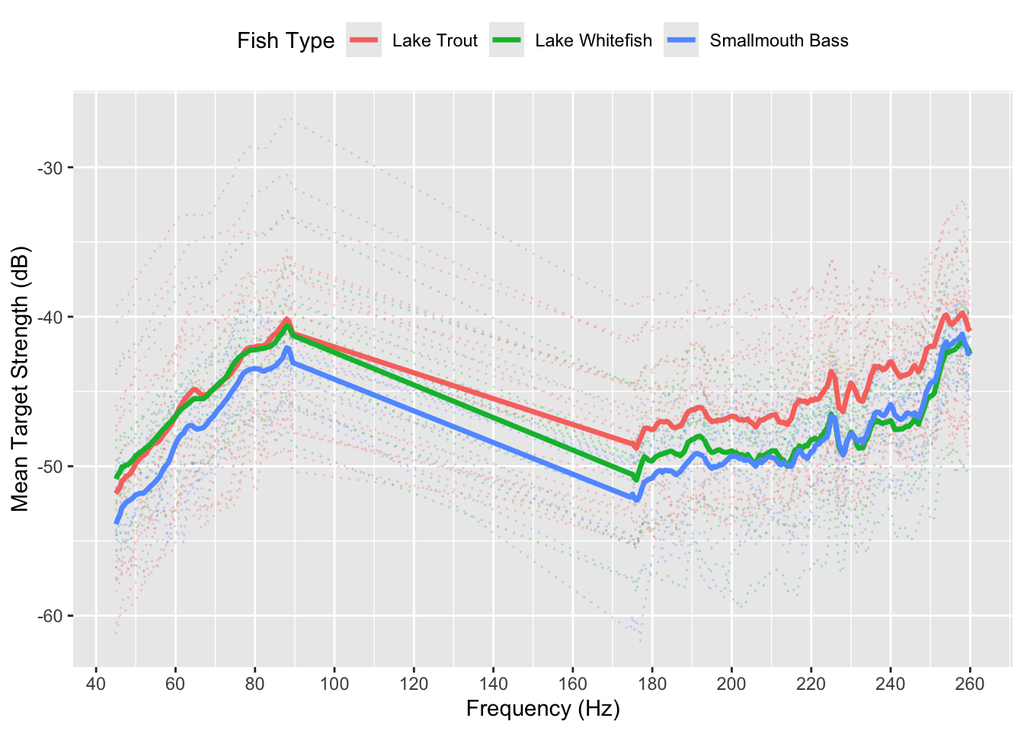

```r
(
  ggplot(ts_mean_allTime_data_long, aes(x = Frequency, y = TS_mean_allTime, color = species))
  ## Indiviual fish (dotted lines)
  + geom_line(
    aes(group = interaction(fishNum, species)),
    linetype = "dotted",
    alpha = 0.3,
    linewidth = 0.5
  )
  ## Mean trends (bold lines)
  + stat_summary(
    fun = mean,
    geom = "line",
    aes(group = species),
    linewidth = 1.2
  )
  ## Aesthetics
  + scale_x_continuous(breaks = seq(40, 260, by = 20))
  + labs(
    x = "Frequency (Hz)",
    y = "Mean Target Strength (dB)",
    color = "Fish Type"
  )
  + theme(legend.position = "top")
)
```

Plot to observe the range of frequncies for each individual fish for each species.

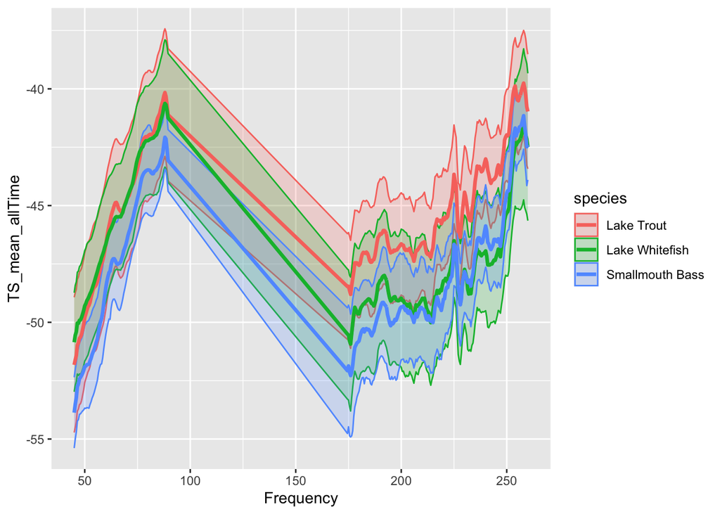

```r
(
  ggplot(ts_mean_allTime_data_long, aes(x = Frequency, y = TS_mean_allTime, color = species))
  + stat_summary(fun.data = mean_cl_normal, geom = "ribbon", alpha = 0.2, aes(fill = species))
  + stat_summary(fun = mean, geom = "line", linewidth = 1.2)
)
```

Plot to observe the range of frequencies of each species separtely.

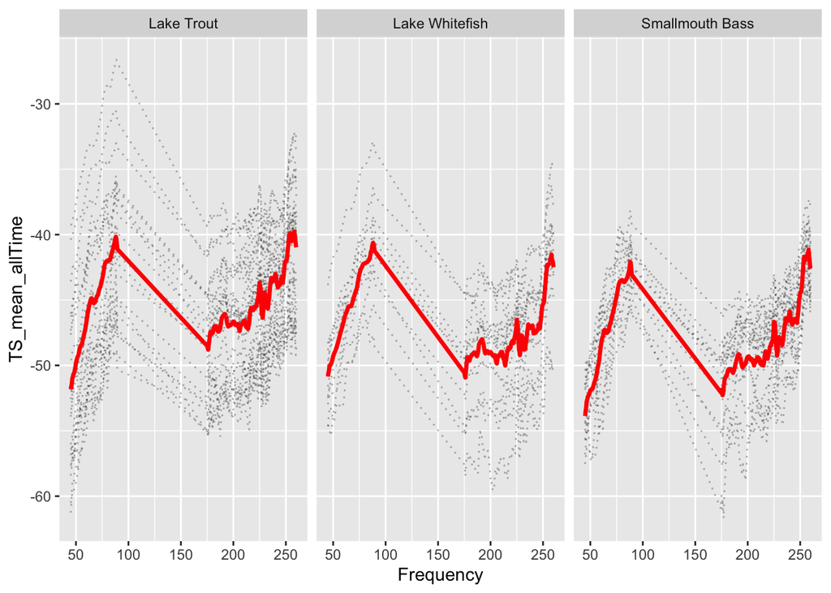

```r
(
  ggplot(ts_mean_allTime_data_long, aes(x = Frequency, y = TS_mean_allTime))
  + geom_line(aes(group = fishNum), linetype = "dotted", alpha = 0.3)
  + stat_summary(fun = mean, geom = "line", color = "red", linewidth = 1.2)
  + facet_wrap(~species)
)
```

Density contour plot to show target strength measurements across differnt frequency ranges for each fish species.

```r
## function to create density contour plot
create_frequency_density_plot <- function(data, title){
#' Create Target Strength Frequency Response Plots
#'
#' This function creates visualization of acoustic target strength data across frequency ranges for fish.
#' The plot combines multiple visualization elements:
#'   - Hexagonal binning to show data density distribution
#'   - Individual fish measurements as dotted gray lines
#'   - Mean target strength trend line in red
#'
#' @param data A long format data frame containing columns in this order: fishNum, species, Frequency, and TS_mean
#' @param title String for the plot title

  colnames(data)[4] <- "TS_mean"

  (
    ggplot(data, aes(x = Frequency, y = TS_mean))
    ## hexbin density layer
    + geom_hex(aes(fill = after_stat(count)), bins = 20, alpha = 0.7)
    ## Indiviiual fish lines
    + geom_line(
      aes(group = interaction(fishNum, species)),
      linetype = "dotted",
      alpha = 0.2,
      color = "gray20"
    )
    ## mean trend
    + stat_summary(
      fun = mean,
      geom = "line",
      color = "red",
      linewidth = 1.2
    )
    ## facet by fish type
    + facet_wrap(~species, nrow = 1)
    ## Aesthetics
    + scale_fill_viridis_c(name = "Data Density")
    + scale_x_continuous(breaks = seq(0, 260, by = 20))
    + labs(title = title, x = "Frequency (Hz)", y = "TS_mean (dB)")
    # + theme_minimal()
    + theme(legend.position = "bottom")
  )
}
```

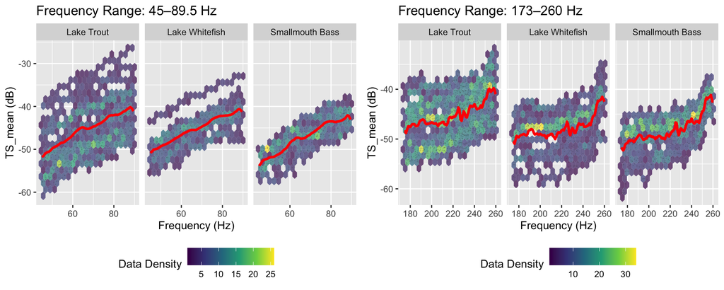

```r
## split data into two frequency groups
ts_mean_allTime_low_long <- ts_mean_allTime_data_long |> filter(Frequency >= 45 & Frequency <= 89.5)
ts_mean_allTime_high_long <- ts_mean_allTime_data_long |> filter(Frequency >= 173 & Frequency <= 260)

# Create plots for both frequency ranges
plot_frequency_density_low <- create_frequency_density_plot(ts_mean_allTime_low_long, "Frequency Range: 45–89.5 Hz")
plot_frequency_density_high <- create_frequency_density_plot(ts_mean_allTime_high_long, "Frequency Range: 173–260 Hz")

# Arrange side-by-side
grid.arrange(plot_frequency_density_low, plot_frequency_density_high, ncol = 2)
```

Create plot of density distribution of target strength by fish species.

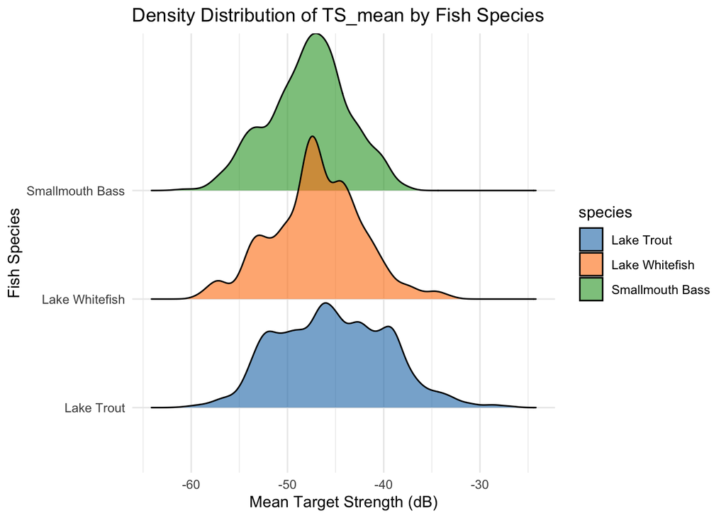

```r
(
  ggplot(ts_mean_allTime_data_long, aes(
    x = TS_mean_allTime,       # Numeric variable for density
    y = species,     # Categorical variable (fish species)
    fill = species   # Color by species
  ))
  ## density ridges
  + geom_density_ridges(alpha = 0.6, scale = 1.5)
  + labs(
    title = "Density Distribution of TS_mean by Fish Species",
    x = "Mean Target Strength (dB)",
    y = "Fish Species"
  )
  + theme_minimal()
  + scale_fill_manual(values = c("#1f77b4", "#ff7f0e", "#2ca02c"))
)
```

We create another density contour plot and we want to observe if there any potential dominant frequency response region by each fish species.

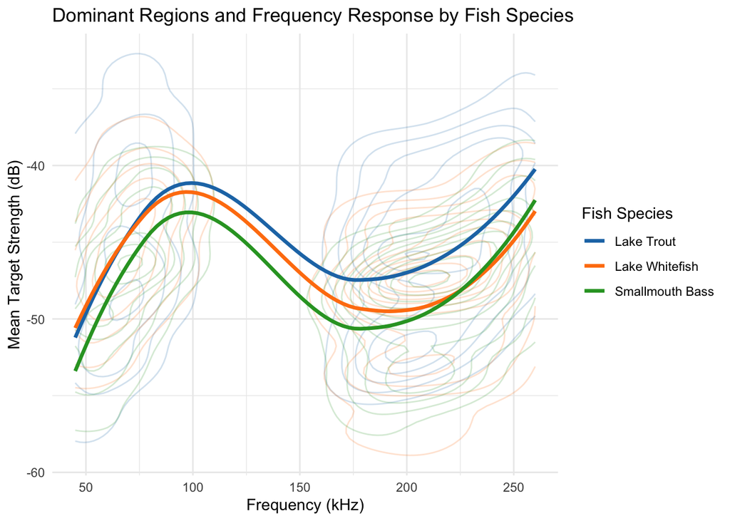

```r
(
  ggplot(ts_mean_allTime_data_long, aes(x = Frequency, y = TS_mean_allTime, color = species))
  ## density contours
  + geom_density_2d(aes(fill = species), alpha = 0.2, contour_var = "density")
  ## frequency response trend lines
  + geom_smooth(
    method = "loess",
    formula = y ~ x,
    se = FALSE,  # Remove confidence bands
    linewidth = 1.2
  )
  ## Aesthetics
  + labs(
    title = "Dominant Regions and Frequency Response by Fish Species",
    x = "Frequency (kHz)",
    y = "Mean Target Strength (dB)",
    color = "Fish Species"
  )
  + scale_color_manual(values = c("#1f77b4", "#ff7f0e", "#2ca02c"))
  + scale_fill_manual(values = c("#1f77b4", "#ff7f0e", "#2ca02c"))
  + theme(legend.position = "bottom")
  + theme_minimal()
)
```

### TS Mean In Fish Species

This section we want to investigate the potential trend / pattern in the frequency response in an indiviual fish species.

#### Lake Trout

```r
LT001_frequency <- LakeTrout[LakeTrout$fishNum == "LT004", ]
# LT001_frequency <- LakeWhiteFish[LakeWhiteFish$fishNum == "LWF003", ]
# LT001_frequency <- SmallmouthBass[SmallmouthBass$fishNum == "SMB005", ]
```

```r
## melt dataframe into plottable format
LT001_frequency$ping_id <- 1:nrow(LT001_frequency)
LT001_frequency_long <- melt(
  LT001_frequency,
  id.vars = c("fishNum", "species", "ping_id"),
  variable.name = "Frequency",
  value.name = "TS"
)
LT001_frequency_long$Frequency <- as.numeric(gsub("F", "",
                                                  LT001_frequency_long$Frequency))
LT001_frequency_long |> head()
```

```
##   fishNum   species ping_id Frequency        TS
## 1   LT004 lakeTrout       1        45 -41.64990
## 2   LT004 lakeTrout       2        45 -44.13450
## 3   LT004 lakeTrout       3        45 -47.54812
## 4   LT004 lakeTrout       4        45 -36.01969
## 5   LT004 lakeTrout       5        45 -35.59207
## 6   LT004 lakeTrout       6        45 -34.82420
```

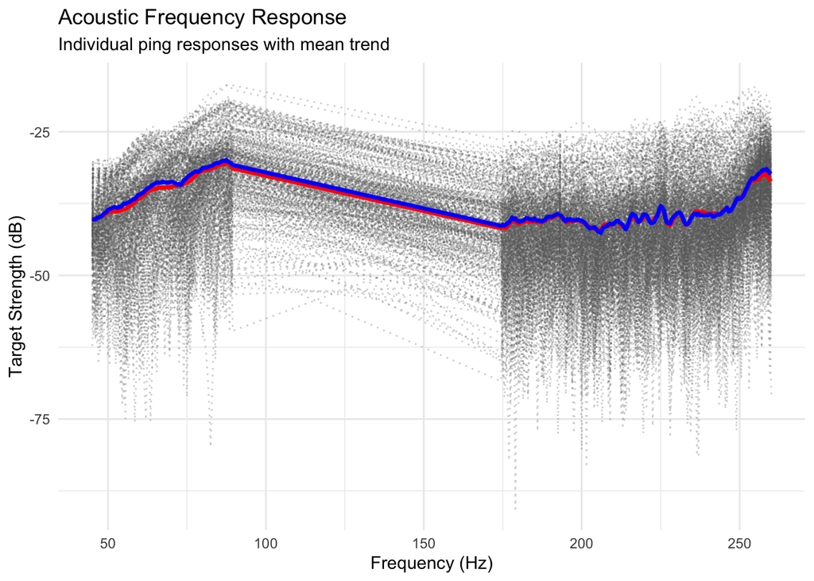

```r
(
  ggplot(LT001_frequency_long, aes(x = Frequency, y = TS))
  ## Indiviual ping time response as dotted lines
  + geom_line(aes(group = ping_id), linetype = "dotted", alpha = 0.3, color = "gray40")
  ## mean respinse as solid line
  + stat_summary(fun = mean, geom = "line", color = "red", linewidth = 1.2)
  + stat_summary(fun = median, geom = "line", color = "blue", linewidth = 1.2)
  ## confidence interval for mean
  # + stat_summary(fun.data = mean_cl_normal, geom = "ribbon", alpha = 0.2, fill = "red")
  + labs(
    title = "Acoustic Frequency Response",
    subtitle = "Individual ping responses with mean trend",
    x = "Frequency (Hz)",
    y = "Target Strength (dB)"
  )
  + theme(
    panel.grid.minor = element_blank(),
    legend.position = "none"
  )
  + theme_minimal()
)
```

Next, we want to compte the difference between the frequency response from the mean from different ping time.

```r
## compute mean
LT001_frequency_mean <- (
  LT001_frequency_long
  |> group_by(Frequency)
  |> summarize(TS_mean = mean(TS, na.rm = TRUE))
)

## left join and compute difference
LT001_frequency_long <- (
  LT001_frequency_long
  |> left_join(LT001_frequency_mean, by = "Frequency")
  |> mutate(diff_from_mean = TS - TS_mean)
)
LT001_frequency_long |> head()
```

```
##   fishNum   species ping_id Frequency        TS   TS_mean diff_from_mean
## 1   LT004 lakeTrout       1        45 -41.64990 -40.39746      -1.252438
## 2   LT004 lakeTrout       2        45 -44.13450 -40.39746      -3.737038
## 3   LT004 lakeTrout       3        45 -47.54812 -40.39746      -7.150657
## 4   LT004 lakeTrout       4        45 -36.01969 -40.39746       4.377772
## 5   LT004 lakeTrout       5        45 -35.59207 -40.39746       4.805394
## 6   LT004 lakeTrout       6        45 -34.82420 -40.39746       5.573259
```

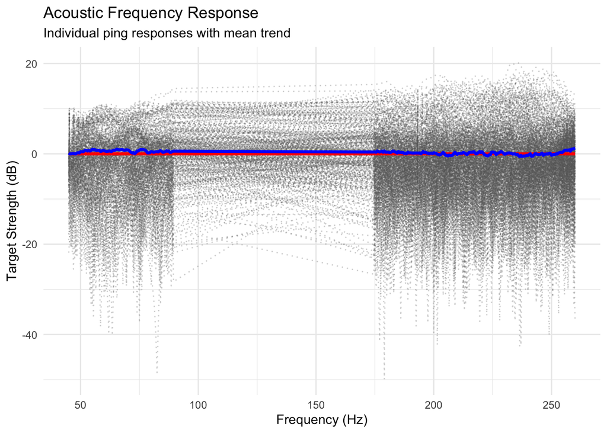

```r
(
  ggplot(LT001_frequency_long, aes(x = Frequency, y = diff_from_mean))
  ## Indiviual ping time response as dotted lines
  + geom_line(aes(group = ping_id), linetype = "dotted", alpha = 0.3, color = "gray40")
  ## mean respinse as solid line
  + stat_summary(fun = mean, geom = "line", color = "red", linewidth = 1.2)
  + stat_summary(fun = median, geom = "line", color = "blue", linewidth = 1.2)
  ## confidence interval for mean
  # + stat_summary(fun.data = mean_cl_normal, geom = "ribbon", alpha = 0.2, fill = "red")
  + labs(
    title = "Acoustic Frequency Response",
    subtitle = "Individual ping responses with mean trend",
    x = "Frequency (Hz)",
    y = "Target Strength (dB)"
  )
  + theme(
    panel.grid.minor = element_blank(),
    legend.position = "none"
  )
  + theme_minimal()
)
```

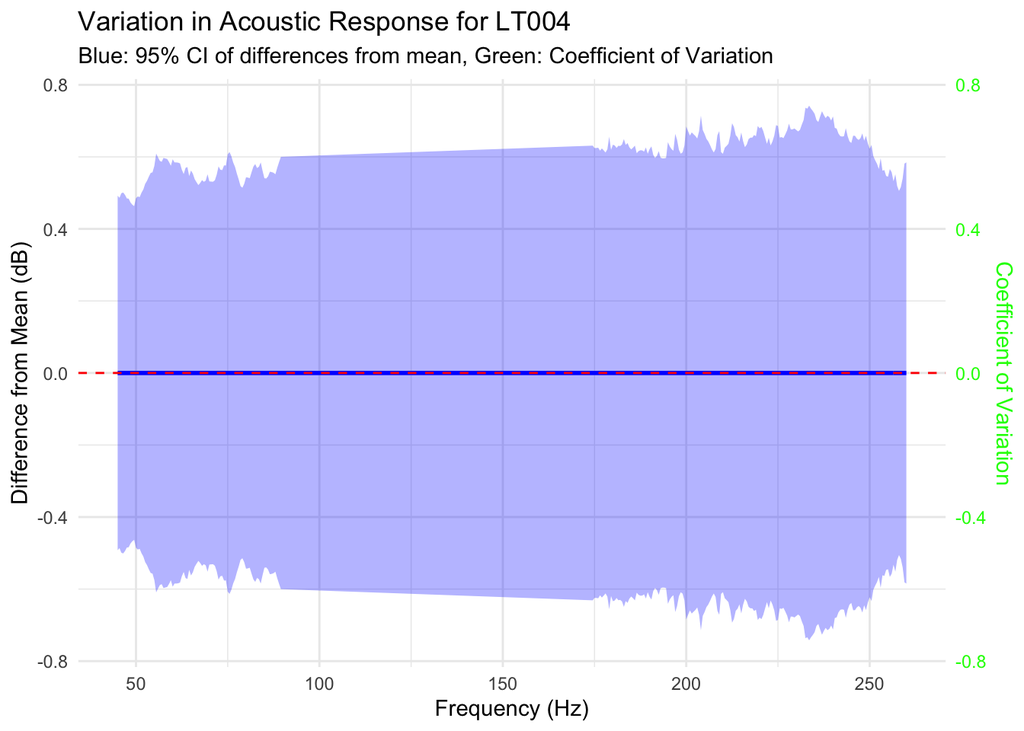

```r
# Calculate confidence intervals for the differences from mean
ci_data <- LT001_frequency_long %>%
  group_by(Frequency) %>%
  summarize(
    mean_diff = mean(diff_from_mean, na.rm = TRUE),
    sd_diff = sd(diff_from_mean, na.rm = TRUE),
    n = n(),
    # Calculate 95% confidence interval
    ci_lower = mean_diff - qt(0.975, n-1) * sd_diff / sqrt(n),
    ci_upper = mean_diff + qt(0.975, n-1) * sd_diff / sqrt(n),
    # Calculate variability metrics
    cv = sd_diff / abs(mean_diff + 0.0001), # Coefficient of variation (adding small constant to avoid div by 0)
    range = max(diff_from_mean, na.rm = TRUE) - min(diff_from_mean, na.rm = TRUE)
  )

# Create a visualization of the confidence intervals
ggplot(ci_data, aes(x = Frequency)) +
  # Add confidence interval as ribbon
  geom_ribbon(aes(ymin = ci_lower, ymax = ci_upper), alpha = 0.3, fill = "blue") +
  # Add mean line
  geom_line(aes(y = mean_diff), color = "blue", linewidth = 1) +
  # Add zero reference line
  geom_hline(yintercept = 0, linetype = "dashed", color = "red") +
  # Add variability plot
  # geom_line(aes(y = cv), color = "green", linewidth = 1) +
  # Create second y-axis for coefficient of variation
  scale_y_continuous(
    name = "Difference from Mean (dB)",
    sec.axis = sec_axis(~ ., name = "Coefficient of Variation")
  ) +
  labs(
    title = paste("Variation in Acoustic Response for", unique(LT001_frequency_long$fishNum)),
    subtitle = "Blue: 95% CI of differences from mean, Green: Coefficient of Variation",
    x = "Frequency (Hz)"
  ) +
  theme_minimal() +
  theme(
    axis.title.y.right = element_text(color = "green"),
    axis.text.y.right = element_text(color = "green")
  )
```

#### Principal Component Analysis

We want to perform PCA in Lake Trout and we want to see if specified frequencies is contributing strongly to the variance of Lake Trout.

```r
## aggregating dataframe into mean frquencies by each fish and scale
LakeTrout_agg <- (
  LakeTrout
  |> group_by(fishNum)
  |> filter(fishNum != "LT008") ## contains missing bal
  |> summarise(across(starts_with("F"), mean, na.rm = TRUE))
  |> ungroup()
  |> dplyr::select(-fishNum)
  |> scale()
)
```

```r
LakeTrout_pca <- PCA(LakeTrout_agg, graph = FALSE)
LakeTrout_pca$eig
```

```
##           eigenvalue percentage of variance cumulative percentage of variance
## comp 1  244.16789037           93.193851286                          93.19385
## comp 2   12.02003492            4.587799588                          97.78165
## comp 3    1.24437091            0.474950730                          98.25660
## comp 4    1.04742834            0.399781810                          98.65638
## comp 5    0.92217886            0.351976665                          99.00836
## comp 6    0.60812085            0.232107195                          99.24047
## comp 7    0.42965637            0.163990981                          99.40446
## comp 8    0.26583564            0.101463984                          99.50592
## comp 9    0.23037531            0.087929508                          99.59385
## comp 10   0.22165497            0.084601135                          99.67845
## comp 11   0.17332964            0.066156351                          99.74461
## comp 12   0.14534112            0.055473711                          99.80008
## comp 13   0.12490007            0.047671783                          99.84775
## comp 14   0.10664779            0.040705262                          99.88846
## comp 15   0.08743621            0.033372598                          99.92183
## comp 16   0.07918201            0.030222140                          99.95205
## comp 17   0.06882798            0.026270221                          99.97832
## comp 18   0.03113712            0.011884397                          99.99021
## comp 19   0.02565152            0.009790656                         100.00000
```

```r
LakeTrout_loadings_pc1 <-(
  LakeTrout_pca$var$coord[, 1]
  |> as.data.frame()
  |> rename(Loading = "LakeTrout_pca$var$coord[, 1]")
  |> mutate(Frequency = rownames(LakeTrout_pca$var$coord))
  |> arrange(desc(abs(Loading)))
)
# loadings_pc1
LakeTrout_loadings_pc1_top_frequencies <- LakeTrout_loadings_pc1 |> head(20)
print(LakeTrout_loadings_pc1_top_frequencies)
```

```
##          Loading Frequency
## F192.5 0.9917266    F192.5
## F193   0.9910375      F193
## F192   0.9907443      F192
## F174.5 0.9905604    F174.5
## F186.5 0.9900472    F186.5
## F185.5 0.9898159    F185.5
## F219   0.9898037      F219
## F186   0.9897930      F186
## F184.5 0.9897452    F184.5
## F201   0.9894583      F201
## F191.5 0.9893738    F191.5
## F193.5 0.9893149    F193.5
## F175   0.9887734      F175
## F185   0.9886990      F185
## F187   0.9885353      F187
## F184   0.9883678      F184
## F191   0.9879483      F191
## F190.5 0.9878434    F190.5
## F200.5 0.9877263    F200.5
## F219.5 0.9875108    F219.5
```

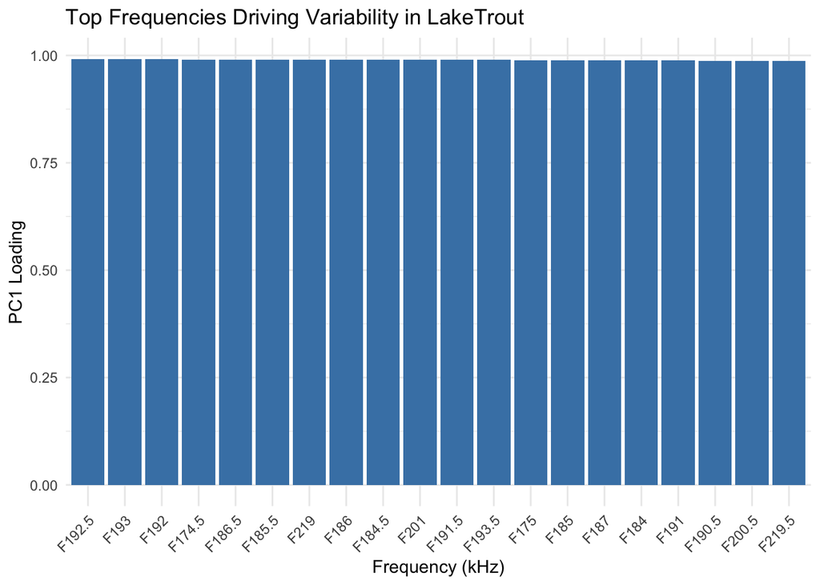

```r
ggplot(LakeTrout_loadings_pc1_top_frequencies, aes(x = reorder(Frequency, -abs(Loading)), y = Loading)) +
  geom_bar(stat = "identity", fill = "steelblue") +
  labs(title = "Top Frequencies Driving Variability in LakeTrout",
       x = "Frequency (kHz)", y = "PC1 Loading") +
  theme_minimal() +
  theme(axis.text.x = element_text(angle = 45, hjust = 1))
```

```r
cor_mat <- cor(LakeTrout_agg) |> as.data.frame()
cor_mat |> head()
```

```
##             F45     F45.5       F46     F46.5       F47     F47.5       F48
## F45   1.0000000 0.9996056 0.9984781 0.9963892 0.9938490 0.9907588 0.9873195
## F45.5 0.9996056 1.0000000 0.9994420 0.9977076 0.9952274 0.9922555 0.9889508
## F46   0.9984781 0.9994420 1.0000000 0.9991627 0.9970995 0.9944152 0.9912062
## F46.5 0.9963892 0.9977076 0.9991627 1.0000000 0.9992304 0.9974915 0.9950857
## F47   0.9938490 0.9952274 0.9970995 0.9992304 1.0000000 0.9993983 0.9979255
## F47.5 0.9907588 0.9922555 0.9944152 0.9974915 0.9993983 1.0000000 0.9995045
##           F48.5       F49     F49.5       F50     F50.5       F51     F51.5
## F45   0.9854044 0.9867684 0.9875213 0.9879263 0.9864481 0.9846682 0.9823516
## F45.5 0.9872332 0.9884595 0.9890266 0.9890938 0.9875503 0.9859041 0.9838920
## F46   0.9899854 0.9910707 0.9913655 0.9911944 0.9896404 0.9880390 0.9861063
## F46.5 0.9942902 0.9948713 0.9945583 0.9936412 0.9917328 0.9898139 0.9879700
## F47   0.9972634 0.9976006 0.9969827 0.9954719 0.9931085 0.9906675 0.9892975
## F47.5 0.9990207 0.9990787 0.9982728 0.9964518 0.9938612 0.9912456 0.9897838
##             F52     F52.5       F53     F53.5       F54     F54.5       F55
## F45   0.9784427 0.9752323 0.9749124 0.9758274 0.9793099 0.9835452 0.9865828
## F45.5 0.9802075 0.9773009 0.9769559 0.9776729 0.9810197 0.9851049 0.9878685
## F46   0.9829682 0.9805702 0.9800609 0.9805476 0.9836110 0.9872657 0.9894391
## F46.5 0.9852680 0.9833675 0.9826165 0.9825025 0.9848524 0.9877872 0.9891125
## F47   0.9868246 0.9849949 0.9844540 0.9838143 0.9851698 0.9869363 0.9871556
## F47.5 0.9870537 0.9850853 0.9841743 0.9827655 0.9833158 0.9843635 0.9839844
##           F55.5       F56     F56.5       F57     F57.5       F58     F58.5
## F45   0.9882379 0.9880204 0.9868946 0.9849491 0.9826938 0.9790282 0.9742466
## F45.5 0.9893801 0.9891469 0.9880760 0.9865137 0.9845111 0.9811511 0.9767838
## F46   0.9904948 0.9904018 0.9896441 0.9886293 0.9868956 0.9840928 0.9805374
## F46.5 0.9894972 0.9889457 0.9883278 0.9880547 0.9869264 0.9850078 0.9824732
## F47   0.9869529 0.9858366 0.9851733 0.9853552 0.9846066 0.9832537 0.9813668
## F47.5 0.9833049 0.9818024 0.9810931 0.9815788 0.9811626 0.9803480 0.9789828
##             F59     F59.5       F60     F60.5       F61     F61.5       F62
## F45   0.9726974 0.9729084 0.9747031 0.9755038 0.9760930 0.9759473 0.9755610
## F45.5 0.9755277 0.9758662 0.9774892 0.9781902 0.9786538 0.9784071 0.9779916
## F46   0.9798032 0.9803538 0.9819924 0.9827455 0.9832965 0.9831439 0.9827446
## F46.5 0.9826682 0.9838174 0.9856276 0.9865472 0.9872740 0.9870454 0.9864016
## F47   0.9822194 0.9841360 0.9863297 0.9876743 0.9888113 0.9887047 0.9880671
## F47.5 0.9805389 0.9831913 0.9858067 0.9875771 0.9891117 0.9890382 0.9884401
##           F62.5       F63     F63.5       F64     F64.5       F65     F65.5
## F45   0.9749474 0.9763192 0.9770825 0.9752035 0.9721714 0.9702102 0.9690829
## F45.5 0.9773644 0.9785647 0.9791646 0.9773056 0.9743185 0.9721607 0.9707896
## F46   0.9819044 0.9827168 0.9829475 0.9809075 0.9778756 0.9758360 0.9744647
## F46.5 0.9853464 0.9856095 0.9853228 0.9830642 0.9798341 0.9779481 0.9766652
```

[output cut: 211 more lines]

```
## F47.5 0.8105999 0.8087133 0.8106671 0.8311265 0.8469944 0.8498602 0.8456638
##          F255.5      F256    F256.5      F257    F257.5      F258    F258.5
## F45   0.8490578 0.8640935 0.8672562 0.8587325 0.8309907 0.8401535 0.8497166
## F45.5 0.8511738 0.8655596 0.8681721 0.8602313 0.8328851 0.8414124 0.8504737
## F46   0.8531286 0.8659914 0.8677359 0.8602365 0.8333260 0.8414542 0.8501398
## F46.5 0.8532012 0.8638956 0.8651321 0.8586462 0.8323266 0.8405863 0.8494949
## F47   0.8487535 0.8594512 0.8613242 0.8562778 0.8315986 0.8391294 0.8475065
## F47.5 0.8467361 0.8564972 0.8589619 0.8551134 0.8312648 0.8386555 0.8468001
##            F259    F259.5      F260
## F45   0.8545820 0.8681942 0.8789833
## F45.5 0.8551806 0.8683175 0.8795463
## F46   0.8544393 0.8673357 0.8799208
## F46.5 0.8525322 0.8652120 0.8779067
## F47   0.8493740 0.8616816 0.8744375
## F47.5 0.8481206 0.8605872 0.8729284
```

### Lake White Fish

#### PCA

```r
is.na(LakeWhiteFish) |> sum()
```

```
## [1] 0
```

```r
## aggregating dataframe into mean frquencies by each fish and scale
LakeWhiteFish_agg <- (
  LakeWhiteFish
  |> group_by(fishNum)
  |> summarise(across(starts_with("F"), mean, na.rm = TRUE))
  |> ungroup()
  |> dplyr::select(-fishNum)
  |> scale()
)

LakeWhiteFish_pca <- PCA(LakeWhiteFish_agg, graph = FALSE)
LakeWhiteFish_pca$eig
```

```
##          eigenvalue percentage of variance cumulative percentage of variance
## comp 1  231.8110033            88.47748219                          88.47748
## comp 2   22.5642327             8.61230257                          97.08978
## comp 3    3.1898340             1.21749388                          98.30728
## comp 4    1.3002044             0.49626123                          98.80354
## comp 5    1.2483222             0.47645884                          99.28000
## comp 6    0.6863313             0.26195852                          99.54196
## comp 7    0.4804654             0.18338374                          99.72534
## comp 8    0.3544151             0.13527292                          99.86061
## comp 9    0.2359243             0.09004743                          99.95066
## comp 10   0.1292673             0.04933866                         100.00000
```

```r
LakeWhiteFish_loadings_pc1 <-(
  LakeWhiteFish_pca$var$coord[, 1]
  |> as.data.frame()
  |> rename(Loading = "LakeWhiteFish_pca$var$coord[, 1]")
  |> mutate(Frequency = rownames(LakeWhiteFish_pca$var$coord))
  |> arrange(desc(abs(Loading)))
)
# loadings_pc1
LakeWhiteFish_loadings_pc1_top_frequencies <- LakeWhiteFish_loadings_pc1 |> head(20)
print(LakeWhiteFish_loadings_pc1_top_frequencies)
```

```
##          Loading Frequency
## F177   0.9922075      F177
## F177.5 0.9920973    F177.5
## F181.5 0.9914840    F181.5
## F179   0.9913680      F179
## F179.5 0.9911363    F179.5
## F176.5 0.9910255    F176.5
## F178   0.9908949      F178
## F191.5 0.9906787    F191.5
## F178.5 0.9906741    F178.5
## F192   0.9905841      F192
## F182   0.9901619      F182
## F181   0.9899581      F181
## F187   0.9897694      F187
## F192.5 0.9894007    F192.5
## F189   0.9891863      F189
## F180   0.9890492      F180
## F191   0.9890019      F191
## F189.5 0.9889616    F189.5
## F180.5 0.9883996    F180.5
## F187.5 0.9883566    F187.5
```

#### Smallmouth Bass

```r
is.na(SmallmouthBass) |> sum()
```

```
## [1] 0
```

```r
## aggregating dataframe into mean frquencies by each fish and scale
SmallmouthBass_agg <- (
  SmallmouthBass
  |> group_by(fishNum)
  |> summarise(across(starts_with("F"), mean, na.rm = TRUE))
  |> ungroup()
  |> dplyr::select(-fishNum)
  |> scale()
)

SmallmouthBass_pca <- PCA(SmallmouthBass_agg, graph = FALSE)
SmallmouthBass_pca$eig
```

```
##          eigenvalue percentage of variance cumulative percentage of variance
## comp 1  213.3072959             81.4149985                          81.41500
## comp 2   23.5759162              8.9984413                          90.41344
## comp 3   11.5596728              4.4120889                          94.82553
## comp 4    4.2400843              1.6183528                          96.44388
## comp 5    2.6129396              0.9973052                          97.44119
## comp 6    2.0342874              0.7764456                          98.21763
## comp 7    1.3981600              0.5336489                          98.75128
## comp 8    1.1297422              0.4311993                          99.18248
## comp 9    0.9487046              0.3621010                          99.54458
## comp 10   0.7398264              0.2823765                          99.82696
## comp 11   0.4533705              0.1730422                         100.00000
```

```r
SmallmouthBass_loadings_pc1 <-(
  SmallmouthBass_pca$var$coord[, 1]
  |> as.data.frame()
  |> rename(Loading = "SmallmouthBass_pca$var$coord[, 1]")
  |> mutate(Frequency = rownames(SmallmouthBass_pca$var$coord))
  |> arrange(desc(abs(Loading)))
)
# loadings_pc1
SmallmouthBass_loadings_pc1_top_frequencies <- SmallmouthBass_loadings_pc1 |> head(20)
print(SmallmouthBass_loadings_pc1_top_frequencies)
```

```
##          Loading Frequency
## F208   0.9897276      F208
## F209   0.9889544      F209
## F209.5 0.9879459    F209.5
## F208.5 0.9868680    F208.5
## F184.5 0.9855797    F184.5
## F210.5 0.9855452    F210.5
## F210   0.9845995      F210
## F212   0.9831610      F212
## F184   0.9825360      F184
## F212.5 0.9818542    F212.5
## F207.5 0.9817102    F207.5
## F211   0.9814438      F211
## F185   0.9808391      F185
## F183.5 0.9795990    F183.5
## F211.5 0.9793790    F211.5
## F205   0.9788696      F205
## F205.5 0.9788447    F205.5
## F213.5 0.9781155    F213.5
## F207   0.9775793      F207
## F214   0.9767587      F214
```

```r
(SmallmouthBass
  |> group_by(fishNum)
  |> summarise(across(starts_with("F"), mean, na.rm = TRUE))
  |> ungroup()
  |> dplyr::select(-fishNum)
 |> summarise(across(starts_with("F"), mean, na.rm = TRUE))
 )
```

```
## # A tibble: 1 × 262
##     F45 F45.5   F46 F46.5   F47 F47.5   F48 F48.5   F49 F49.5   F50 F50.5   F51
##   <dbl> <dbl> <dbl> <dbl> <dbl> <dbl> <dbl> <dbl> <dbl> <dbl> <dbl> <dbl> <dbl>
## 1 -53.9 -53.5 -53.2 -52.8 -52.6 -52.4 -52.4 -52.3 -52.2 -52.1 -51.9 -51.9 -51.8
## # ℹ 249 more variables: F51.5 <dbl>, F52 <dbl>, F52.5 <dbl>, F53 <dbl>,
## #   F53.5 <dbl>, F54 <dbl>, F54.5 <dbl>, F55 <dbl>, F55.5 <dbl>, F56 <dbl>,
## #   F56.5 <dbl>, F57 <dbl>, F57.5 <dbl>, F58 <dbl>, F58.5 <dbl>, F59 <dbl>,
## #   F59.5 <dbl>, F60 <dbl>, F60.5 <dbl>, F61 <dbl>, F61.5 <dbl>, F62 <dbl>,
## #   F62.5 <dbl>, F63 <dbl>, F63.5 <dbl>, F64 <dbl>, F64.5 <dbl>, F65 <dbl>,
## #   F65.5 <dbl>, F66 <dbl>, F66.5 <dbl>, F67 <dbl>, F67.5 <dbl>, F68 <dbl>,
## #   F68.5 <dbl>, F69 <dbl>, F69.5 <dbl>, F70 <dbl>, F70.5 <dbl>, F71 <dbl>, …
```

### Overall PCA

```r
LT_mean_frequency <- (
  LakeTrout
  |> group_by(fishNum)
  |> filter(fishNum != "LT008")
  |> dplyr::select(matches("^F(1[7-9][0-9](\\.[0-9])?|2[0-5][0-9](\\.[0-9])?|260(\\.[0-9])?)$"))
  |> summarise(across(starts_with("F"), mean, na.rm = TRUE))
  |> ungroup()
  |> dplyr::select(-fishNum)
  |> summarise(across(starts_with("F"), mean, na.rm = TRUE))
)
LT_mean_frequency |> head()
```

```
## # A tibble: 1 × 172
##   F174.5  F175 F175.5  F176 F176.5  F177 F177.5  F178 F178.5  F179 F179.5  F180
##    <dbl> <dbl>  <dbl> <dbl>  <dbl> <dbl>  <dbl> <dbl>  <dbl> <dbl>  <dbl> <dbl>
## 1  -48.5 -48.5  -48.6 -48.8  -48.4 -48.1  -47.8 -47.5  -47.5 -47.5  -47.5 -47.6
## # ℹ 160 more variables: F180.5 <dbl>, F181 <dbl>, F181.5 <dbl>, F182 <dbl>,
## #   F182.5 <dbl>, F183 <dbl>, F183.5 <dbl>, F184 <dbl>, F184.5 <dbl>,
## #   F185 <dbl>, F185.5 <dbl>, F186 <dbl>, F186.5 <dbl>, F187 <dbl>,
## #   F187.5 <dbl>, F188 <dbl>, F188.5 <dbl>, F189 <dbl>, F189.5 <dbl>,
## #   F190 <dbl>, F190.5 <dbl>, F191 <dbl>, F191.5 <dbl>, F192 <dbl>,
## #   F192.5 <dbl>, F193 <dbl>, F193.5 <dbl>, F194 <dbl>, F194.5 <dbl>,
## #   F195 <dbl>, F195.5 <dbl>, F196 <dbl>, F196.5 <dbl>, F197 <dbl>, …
```

```r
LWF_mean_frequency <- (
  LakeWhiteFish
  |> group_by(fishNum)
  |> dplyr::select(matches("^F(1[7-9][0-9](\\.[0-9])?|2[0-5][0-9](\\.[0-9])?|260(\\.[0-9])?)$"))
  |> summarise(across(starts_with("F"), mean, na.rm = TRUE))
  |> ungroup()
  |> dplyr::select(-fishNum)
  |> summarise(across(starts_with("F"), mean, na.rm = TRUE))
)
LWF_mean_frequency |> head()
```

```
## # A tibble: 1 × 172
##   F174.5  F175 F175.5  F176 F176.5  F177 F177.5  F178 F178.5  F179 F179.5  F180
##    <dbl> <dbl>  <dbl> <dbl>  <dbl> <dbl>  <dbl> <dbl>  <dbl> <dbl>  <dbl> <dbl>
## 1  -50.5 -50.5  -50.8 -50.9  -50.5 -50.0  -49.7 -49.4  -49.5 -49.6  -49.6 -49.6
## # ℹ 160 more variables: F180.5 <dbl>, F181 <dbl>, F181.5 <dbl>, F182 <dbl>,
## #   F182.5 <dbl>, F183 <dbl>, F183.5 <dbl>, F184 <dbl>, F184.5 <dbl>,
## #   F185 <dbl>, F185.5 <dbl>, F186 <dbl>, F186.5 <dbl>, F187 <dbl>,
## #   F187.5 <dbl>, F188 <dbl>, F188.5 <dbl>, F189 <dbl>, F189.5 <dbl>,
## #   F190 <dbl>, F190.5 <dbl>, F191 <dbl>, F191.5 <dbl>, F192 <dbl>,
## #   F192.5 <dbl>, F193 <dbl>, F193.5 <dbl>, F194 <dbl>, F194.5 <dbl>,
## #   F195 <dbl>, F195.5 <dbl>, F196 <dbl>, F196.5 <dbl>, F197 <dbl>, …
```

```r
SB_mean_frequency <- (
  SmallmouthBass
  |> group_by(fishNum)
  |> dplyr::select(matches("^F(1[7-9][0-9](\\.[0-9])?|2[0-5][0-9](\\.[0-9])?|260(\\.[0-9])?)$"))
  |> summarise(across(starts_with("F"), mean, na.rm = TRUE))
  |> ungroup()
  |> dplyr::select(-fishNum)
  |> summarise(across(starts_with("F"), mean, na.rm = TRUE))
)
SB_mean_frequency |> head()
```

```
## # A tibble: 1 × 172
##   F174.5  F175 F175.5  F176 F176.5  F177 F177.5  F178 F178.5  F179 F179.5  F180
##    <dbl> <dbl>  <dbl> <dbl>  <dbl> <dbl>  <dbl> <dbl>  <dbl> <dbl>  <dbl> <dbl>
## 1  -52.1 -51.9  -52.1 -52.3  -52.2 -51.8  -51.4 -51.1  -51.0 -50.9  -50.8 -50.8
## # ℹ 160 more variables: F180.5 <dbl>, F181 <dbl>, F181.5 <dbl>, F182 <dbl>,
## #   F182.5 <dbl>, F183 <dbl>, F183.5 <dbl>, F184 <dbl>, F184.5 <dbl>,
## #   F185 <dbl>, F185.5 <dbl>, F186 <dbl>, F186.5 <dbl>, F187 <dbl>,
## #   F187.5 <dbl>, F188 <dbl>, F188.5 <dbl>, F189 <dbl>, F189.5 <dbl>,
## #   F190 <dbl>, F190.5 <dbl>, F191 <dbl>, F191.5 <dbl>, F192 <dbl>,
## #   F192.5 <dbl>, F193 <dbl>, F193.5 <dbl>, F194 <dbl>, F194.5 <dbl>,
## #   F195 <dbl>, F195.5 <dbl>, F196 <dbl>, F196.5 <dbl>, F197 <dbl>, …
```

```r
## prepare fish species PCA comparison data
prepare_species_PCA_data <- function(species, mean_freq_df, loadings_df) {

  ## convery mean frequecy data to long format
  species_long <- melt(
    mean_freq_df,
    variable.name = "Frequency",
    value.name = "TS"

  )
  ## removing "F" from frequency and make it numerical
  species_long$Frequency <- as.numeric(gsub("F", "",
                                            species_long$Frequency))
  loadings_df$Frequency <- as.numeric(gsub("F", "",
                                            loadings_df$Frequency))

  ## Add species name
  species_long$Species <- species

  ## join with loadings
  species_combined <- merge(
    species_long,
    loadings_df[, c("Frequency", "Loading")],
    by = "Frequency",
    all.x = TRUE
  )

  return(species_combined)
}
```

```r
## prepare PCA data for each species
LakeTrout_PCA_data <- prepare_species_PCA_data(
  "Lake Trout",
  LT_mean_frequency,
  LakeTrout_loadings_pc1
)
LakeWhiteFish_PCA_data <- prepare_species_PCA_data(
  "Lake Whitefish",
  LWF_mean_frequency,
  LakeWhiteFish_loadings_pc1
)
SmallmouthBass_PCA_data <- prepare_species_PCA_data(
  "Smallmouth Bass",
  SB_mean_frequency,
  SmallmouthBass_loadings_pc1
)
all_species_PCA_data <- rbind(
  LakeTrout_PCA_data,
  LakeWhiteFish_PCA_data,
  SmallmouthBass_PCA_data
)
```

```r
all_species_PCA_data |> head()
```

```
##   Frequency        TS    Species   Loading
## 1     174.5 -48.46775 Lake Trout 0.9905604
## 2     175.0 -48.45928 Lake Trout 0.9887734
## 3     175.5 -48.63499 Lake Trout 0.9829240
## 4     176.0 -48.80316 Lake Trout 0.9720122
## 5     176.5 -48.43520 Lake Trout 0.9716531
## 6     177.0 -48.13510 Lake Trout 0.9768478
```

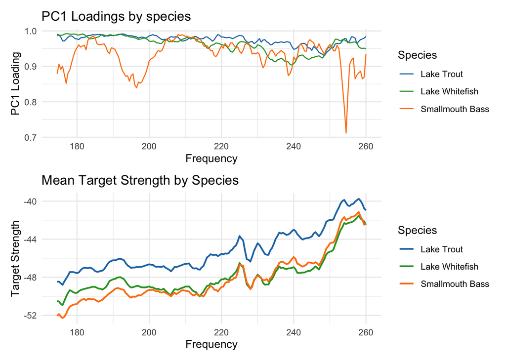

```r
## create plots to show PCA laodings and TS_mean to visulize the PCA data
species_colors <- c(
  "Lake Trout" = "#1f77b4",
  "Lake Whitefish" = "#2ca02c",
  "Smallmouth Bass" = "#ff7f0e"
)

## PCA loading plots
all_species_PCA_plot <- (
  ggplot(all_species_PCA_data,
         aes(x = Frequency, y = Loading, color = Species))
  + geom_line(linewidth = 0.5)
  + scale_color_manual(values = species_colors)
  + labs(
    title = "PC1 Loadings by species",
    y = "PC1 Loading"
  )
  + theme(
    axis.title.x = element_blank(),
    axis.text.x = element_blank(),
    legend.position = "none"
  )
  + theme_minimal()
)

## TS_mean plots
all_species_TS_mean_plot <- (
  ggplot(all_species_PCA_data,
         aes(x = Frequency, y = TS, color = Species))
  + geom_line(linewidth = 0.8)
  + scale_color_manual(values = species_colors)
  + labs(
    title = "Mean Target Strength by Species",
    y = "Target Strength",
    x = "Frequency"
  )
  + theme(
    axis.text.x = element_text(angle = 45, hjust = 1),
    legend.position = "bottom"
  )
  + theme_minimal()
)

## combined plots
all_species_PCA_combined_plot <- (
  all_species_PCA_plot / all_species_TS_mean_plot
  + plot_layout(heights = c(1, 1.2))
)
all_species_PCA_combined_plot
```